# Coarse woody debris: Pre- and post-thinning

Morgan Gray

2022-11-09

## Overview

The aim of this research was to understand the impact of fuel load management (i.e., thinning) on fuels. Our objective was to evaluate the short-term impact of thinning on levels of coarse woody debris (total, and by fuel class). To meet this objective, we used a “treatment and control” approach to compare fuel levels before (control, pre-thinning) and after (treatment, post-thinning) thinning was applied at five vegetation monitoring plots.

The control and treatment data sets were collected at two time points in 2021. Control data were collected before thinning, between 6/9/21 and 7/7/21. Treatment data were collected after thinning on 10/18/21 and 10/19/21, with the exception of measurements for plot FOR10 which surveyed on 12/9/21. On average, 133.6 days elapsed between control and treatment surveys (range: 104 to 183, standard deviation = 27.2).

We used these data to answer the following questions:

1. Did the total fuel load (all coarse woody debris fuel classes combined) differ between control and treatment surveys?
2. Did fuel load for between control and treatment surveys differ by fuel class?

#### Fuel measurements for coarse woody debris mass

We answered these questions using plot-level data collected before and after treatment (i.e., pre- and post-thinning) for (1) the total amount of coarse woody debris and (2) the mean amount of each of the five fuel classes. We defined “total (or all) coarse woody debris” as the combined total of the the five fuel classes within a plot: 1-hr, 10-hr, 100-hr, 1000-hr rotten, 1000-hr sound.

Recall that surveys were conducted along three transects within each plot. We calculated the *plot-level mean for each fuel class* to account for replicate surveys within each plot. To calculated the the *plot-level total* at each time point, we summed the plot means for all CWD fuel classes.

Below is a table that shows the plot-level mean at each time point for coarse woody debris (total and mean by fuel class).

| fuel_class | plot_id | Pre-thin | Post-thin | metric | units |
| --- | --- | --- | --- | --- | --- |
| All | FOR05 | 36.479 | 349.466 | total | MT/ha |
| All | FOR06 | 3.119 | 96.256 | total | MT/ha |
| All | FOR07 | 57.459 | 392.693 | total | MT/ha |
| All | FOR08 | 146.628 | 68.708 | total | MT/ha |
| All | FOR10 | 7.384 | 52.145 | total | MT/ha |
| 1-hr | FOR05 | 1.275 | 1.617 | mean | MT/ha |
| 1-hr | FOR06 | 0.377 | 4.037 | mean | MT/ha |
| 1-hr | FOR07 | 2.842 | 1.936 | mean | MT/ha |
| 1-hr | FOR08 | 0.257 | 0.917 | mean | MT/ha |
| 1-hr | FOR10 | 0.192 | 1.759 | mean | MT/ha |
| 10-hr | FOR05 | 5.106 | 6.034 | mean | MT/ha |
| 10-hr | FOR06 | 1.679 | 5.526 | mean | MT/ha |
| 10-hr | FOR07 | 6.012 | 8.460 | mean | MT/ha |
| 10-hr | FOR08 | 1.447 | 1.988 | mean | MT/ha |
| 10-hr | FOR10 | 2.731 | 3.346 | mean | MT/ha |
| 100-hr | FOR05 | 1.109 | 14.517 | mean | MT/ha |
| 100-hr | FOR06 | 1.062 | 9.780 | mean | MT/ha |
| 100-hr | FOR07 | 3.312 | 8.969 | mean | MT/ha |
| 100-hr | FOR08 | 110.112 | 4.419 | mean | MT/ha |
| 100-hr | FOR10 | 4.461 | 5.514 | mean | MT/ha |
| 1000-hr rotten | FOR05 | 0.000 | 0.000 | mean | MT/ha |
| 1000-hr rotten | FOR06 | 0.000 | 0.000 | mean | MT/ha |
| 1000-hr rotten | FOR07 | 0.000 | 0.000 | mean | MT/ha |
| 1000-hr rotten | FOR08 | 34.811 | 0.000 | mean | MT/ha |
| 1000-hr rotten | FOR10 | 0.000 | 0.000 | mean | MT/ha |
| 1000-hr sound | FOR05 | 28.989 | 327.298 | mean | MT/ha |
| 1000-hr sound | FOR06 | 0.000 | 76.912 | mean | MT/ha |
| 1000-hr sound | FOR07 | 45.293 | 373.329 | mean | MT/ha |
| 1000-hr sound | FOR08 | 0.000 | 61.384 | mean | MT/ha |
| 1000-hr sound | FOR10 | 0.000 | 41.527 | mean | MT/ha |

The data subset for the 1000-hr rotten fuel class was not normally distributed; most values were equal to zero. Specifically, 29 of the 30 transect measurements equaled 0 and 9 of 10 plot-level means were 0 (pre-thin: 4/5, post-thin: 5/5).

| lab_fuel | lab_class | lab_time | count |
| --- | --- | --- | --- |
| Coarse woody debris | 1000-hr rotten | Pre-thinning | 4 |
| Coarse woody debris | 1000-hr rotten | Post-thinning | 5 |
| Coarse woody debris | 1000-hr sound | Pre-thinning | 3 |

#### Statistical methods

Statistically significant differences were identified using repeated measures analysis of variance (ANOVA) and post hoc comparisons. P-values were adjusted using the Bonferroni multiple testing correction method.

[NOTE: A repeated measures ANOVA is appropriate to use for a paired time series (before vs. after, treatment vs. control). For these data in particular, the approach accounts for elements that structure the data set in addition to time. For example, transects within each plot are more likely to be similar than transects between plots.]

The repeated-measures ANOVA is used for analyzing data where same subjects are measured more than once. This test is also referred to as a within-subjects ANOVA or ANOVA with repeated measures. The “within-subjects” term means that the same individuals (here, individuals are plots) are measured on the same outcome variable under different time points. The main goal of a repeated measures ANOVA is to evaluate if there is a statistically significant interaction effect between within-subjects factors in explaining a continuous outcome variable. The repeated measures ANOVA makes the following assumptions about the data:

- No significant outliers in any cell of the design
- Normality: the outcome (or dependent) variable should be approximately normally distributed in each cell of the design
- Assumption of sphericity: the variance of the differences between groups should be equal

We assessed outliers using the the interquartile range (IQR; IQR = Q3 - Q1). Values above Q3 + 1.5xIQR or below Q1 - 1.5xIQR are considered as outliers. Values above Q3 + 3xIQR or below Q1 - 3xIQR are considered as extreme points (or extreme outliers). Q1 and Q3 are the first and third quartile, respectively. Extreme outliers can be due to data entry errors, measurement errors, or unusual values. The outlier may be included if one believes the result will not be substantially affected; this can be evaluated by comparing the result of the ANOVA with and without the outlier.

We assessed normality by visual inspection of a QQ plot for each time point. A QQ plot draws the correlation between a given data and the normal distribution. We also conducted the Shapiro-Wilk test for each time point. Using this method, normally distributed data will have p-value >0.05.

The assumption of sphericity was checked during the computation of the ANOVA test using the R function anova_test() [rstatix package]. The Mauchly’s test was internally used to assess the sphericity assumption, and the Greenhouse-Geisser sphericity correction was automatically applied to factors violating the sphericity assumption.

#### Check assumptions

##### *Check for outliers*

There were no extreme outliers in the data set for total CWD; a non-extreme outlier was found in pre-thinning total at FOR08. There were three extreme outliers by fuel class: pre-thinning 100-hr and 1000-hr rotten in FOR08; post-thinning 1-hr in FOR06. Overall it looks like something was different about FOR08 during pre- and post-thinning surveys.

| fuel_class | time | plot_id | si_value | units | is_outlier | is_extreme |
| --- | --- | --- | --- | --- | --- | --- |
| 100-hr | Pre-thin | FOR08 | 110.112 | MT/ha | TRUE | TRUE |
| 1000-hr rotten | Pre-thin | FOR08 | 34.811 | MT/ha | TRUE | TRUE |
| 1-hr | Post-thin | FOR06 | 4.037 | MT/ha | TRUE | TRUE |

As expected, outliers were seen in the QQ plots created using CWD raw values for 1-hr, 100-hr, and 1000-hr rotten.

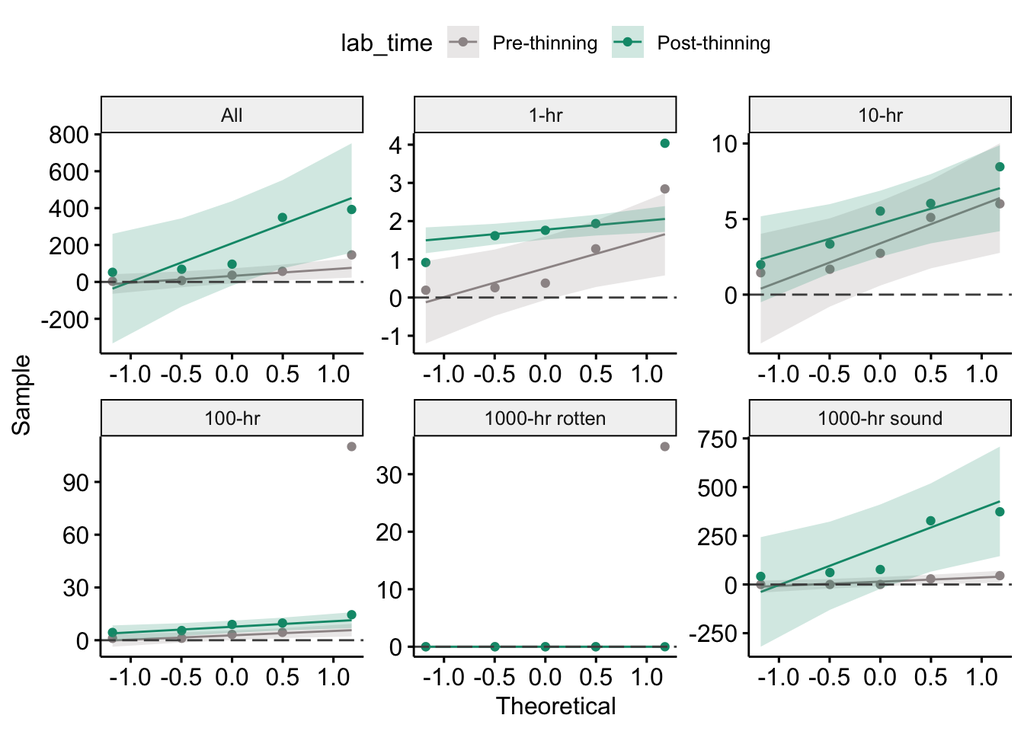

##### *Check for normality*

Shapiro-Wilk’s test indicated that plot-level values were normally distributed for total CWD and for mean CWD within the 1-hr and 10-hr fuel classes. Three fuel classes were not normally distributed: 100-hr, 1000-hr rotten (mostly 0 values), 1000-hr sound.

| lab_class | time | is_normal | p | statistic |
| --- | --- | --- | --- | --- |
| 100-hr | Pre-thin | FALSE | 0.0003236 | 0.579 |
| 1000-hr sound | Pre-thin | FALSE | 0.0448490 | 0.770 |

#### Identify the most appropriate transformation

We applied a series of transformations to each subset, then evaluated the resulting data for outliers and normality. To create the transformed subsets, we used scale() from base R and four normalization functions from the bestNormalize package: arcsinh_x, log_x, orderNorm, and sqrt_x.

| lab_class | fuel_class | time | lab_time_abbr | method | plot_id | number | is_outlier | is_extreme |
| --- | --- | --- | --- | --- | --- | --- | --- | --- |
| 100-hr | hr0100 | t1 | Pre-thin | value_arcsine | FOR08 | 2.231336 | TRUE | FALSE |
| 100-hr | hr0100 | t1 | Pre-thin | value_log | FOR08 | 2.180986 | TRUE | FALSE |
| 100-hr | hr0100 | t1 | Pre-thin | value_norm | FOR08 | 1.644854 | TRUE | FALSE |
| 100-hr | hr0100 | t1 | Pre-thin | value_ordnorm | FOR08 | 1.644854 | TRUE | FALSE |
| 1-hr | hr0001 | t2 | Post-thin | value_norm | FOR06 | 1.644854 | TRUE | FALSE |
| 1-hr | hr0001 | t2 | Post-thin | value_ordnorm | FOR06 | 1.644854 | TRUE | FALSE |

A QQ plot of the values for fuel classes with outliers (rows) by transformation (columns) is below.

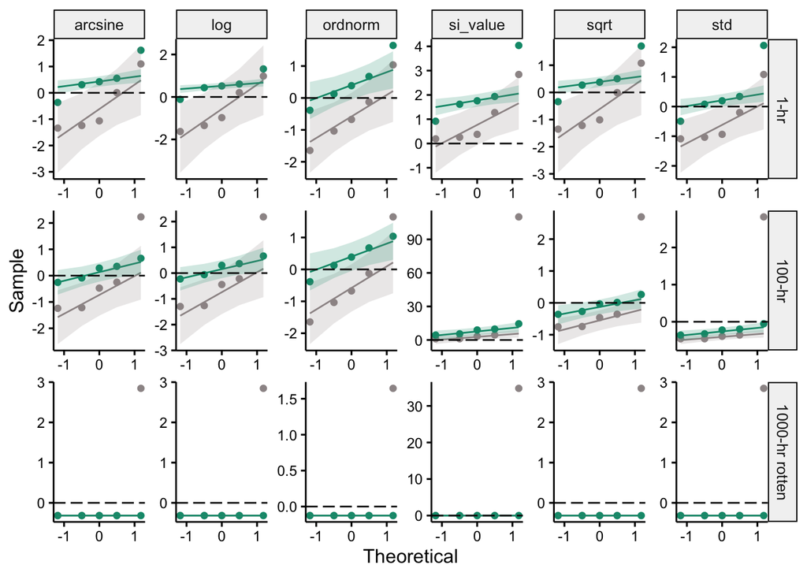

The application of the orderNorm function resulted in values for the 100-hr fuel class that were normally distributed, as assessed by Shapiro-Wilk’s test. No transformation normalized the distribution of the 1000-hr sound subset.

| fuel_class | time | is_normal | method | p | statistic |
| --- | --- | --- | --- | --- | --- |
| hr0100 | t1 | TRUE | value_arcsine | 0.0762655 | 0.7967817 |
| hr0100 | t1 | TRUE | value_log | 0.1061219 | 0.8146592 |
| hr0100 | t1 | TRUE | value_norm | 0.5416692 | 0.9218079 |
| hr0100 | t1 | TRUE | value_ordnorm | 0.5416692 | 0.9218079 |

The following plot shows the values by fuel class (rows) and transformation method (columns). The orderNorm function (green) appeared to be an effective normalization method for most data subsets overall, and was used to tranform CWD values (total and by fuel class).

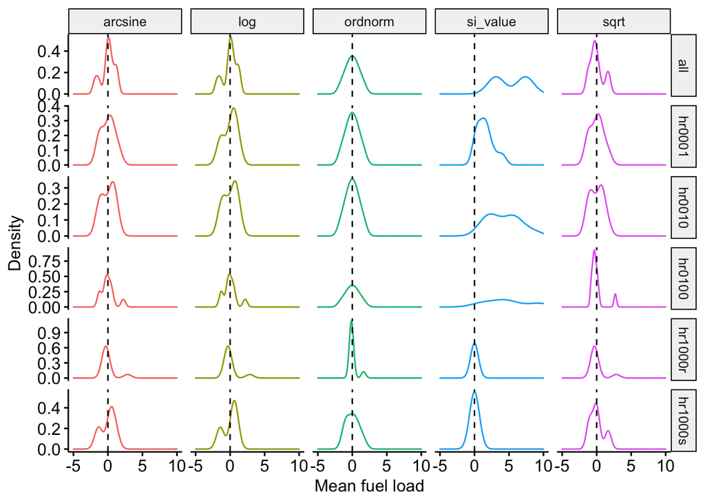

## Total fuel load

### Summary statistics for total fuel load by treatment

The following table summarizes the plot-level total amount of CWD for each time point.

| fuel_type | fuel_class | lab_time | si_units | mean | sd | n |
| --- | --- | --- | --- | --- | --- | --- |
| Coarse woody debris | All | Pre-thinning | Metric tons per hectare | 50.214 | 58.286 | 5 |
| Coarse woody debris | All | Post-thinning | Metric tons per hectare | 191.854 | 165.076 | 5 |

### Visualization of total fuel load by treatment

Visual inspection of a boxplot for total CWD by treatment suggests a post-thinning increase in mass.

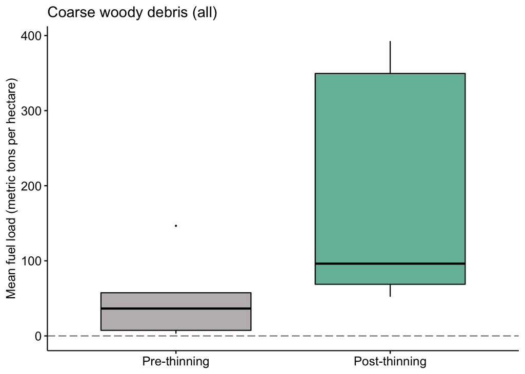

### Main effect of treatment on total fuel load

We found no significant effect of treatment on total fuel load (all CWD fuel classes combined), F(1, 4) = 4.205, p-adj. = 0.11, ges = 0.313. P-values were adjusted using the Bonferroni multiple testing correction method.

| fuel_type | fuel_class | method | effect | p_adj | p_adj_sig | statistic | d_fn | d_fd | ges | index_value |
| --- | --- | --- | --- | --- | --- | --- | --- | --- | --- | --- |
| Coarse woody debris | All | main effect | time | 0.11 | n.s. | 4.205 | 1 | 4 | 0.313 | value_norm |

## Mean fuel load, by fuel class

Next, we investigated whether there was a significant change in plot-level fuel load by treatment when accounting for fuel class. A two-way repeated measures ANOVA was used to determine whether there was a significant interaction between treatment and fuel class on fuel load.

Here, the effect of treatment on fuel load was our focal variable of primary concern. However, the effect of treatment may differ between fuel classes, so fuel_class was considered a moderator variable.

### Summary statistics for mean fuel load by fuel class and treatment

| fuel_type | fuel_class | lab_time | si_units | mean | sd | n |
| --- | --- | --- | --- | --- | --- | --- |
| Coarse woody debris | hr0001 | Pre-thinning | Metric tons per hectare | 0.989 | 1.125 | 5 |
| Coarse woody debris | hr0001 | Post-thinning | Metric tons per hectare | 2.053 | 1.174 | 5 |
| Coarse woody debris | hr0010 | Pre-thinning | Metric tons per hectare | 3.395 | 2.059 | 5 |
| Coarse woody debris | hr0010 | Post-thinning | Metric tons per hectare | 5.071 | 2.505 | 5 |
| Coarse woody debris | hr0100 | Pre-thinning | Metric tons per hectare | 24.011 | 48.154 | 5 |
| Coarse woody debris | hr0100 | Post-thinning | Metric tons per hectare | 8.640 | 3.985 | 5 |
| Coarse woody debris | hr1000r | Pre-thinning | Metric tons per hectare | 6.962 | 15.568 | 5 |
| Coarse woody debris | hr1000r | Post-thinning | Metric tons per hectare | 0.000 | 0.000 | 5 |
| Coarse woody debris | hr1000s | Pre-thinning | Metric tons per hectare | 14.856 | 21.144 | 5 |
| Coarse woody debris | hr1000s | Post-thinning | Metric tons per hectare | 176.090 | 160.365 | 5 |

#### Visualization of mean fuel load by fuel class and treatment

BUT!

What I don’t understand is why the values for the 100-hr fuel class appear to increase after thinning, which is in contrast to the summary statistics that show a decrease in mean values after thinning (pre-thin = 24.01, post-thin = 8.64).

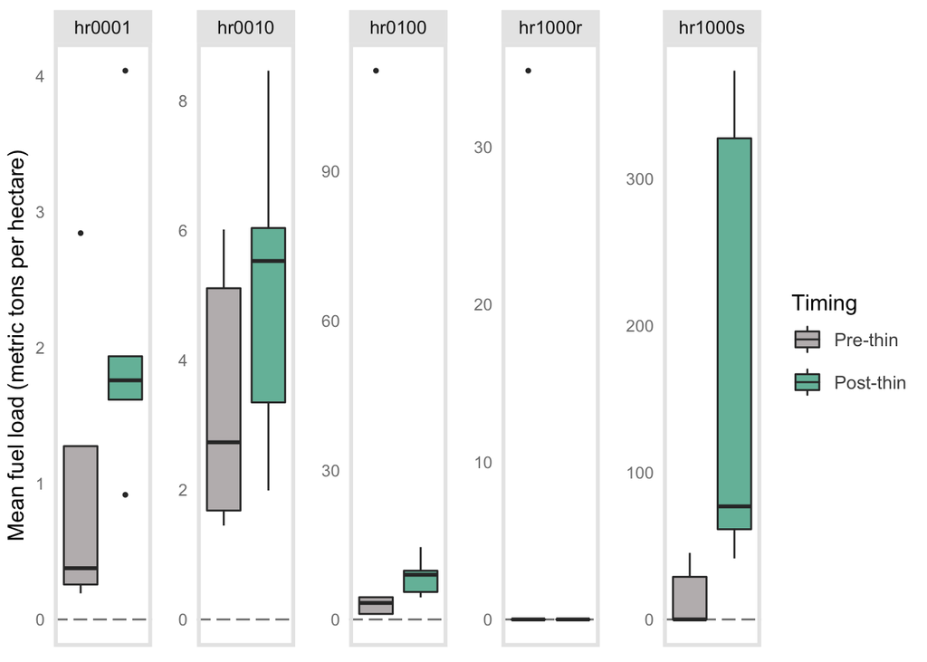

#### Interaction between treatment and fuel class

We wanted to know if the thinning treatment induced a significant change in fuel load among the five fuel classes. In other words, was there a significant interaction between thinning and fuel class on fuel load for coarse woody debris? We conducted a two-way repeated measures ANOVA to evaluate the effect of thinning over different fuel classes on CWD fuel load.

There was no statistically significant interaction between thinning treatment and fuel class on CWD fuel load, F(4, 16) = 2.512, p-adj. = 0.249, ges = 0.141. P-values were adjusted using the Bonferroni multiple testing correction method.

| fuel_type | fuel_class | method | effect | p_adj | p_adj_sig | statistic | d_fn | d_fd | ges | index_value |
| --- | --- | --- | --- | --- | --- | --- | --- | --- | --- | --- |
| Coarse woody debris | By class | interaction | time:fuel_class | 0.249 | n.s. | 2.512 | 4 | 16 | 0.141 | value_norm |

### Effect of treatment on each fuel class

fuel_class

method

p_adj

p_adj_sig

statistic

d_fn

d_fd

ges

index_value

Coarse woody debris

1000-hr sound

main effect

0.00229

111.145

1

4

0.627

value_norm

Coarse woody debris

10-hr

main effect

0.04000

23.752

1

4

0.234

value_norm

Coarse woody debris

1-hr

main effect

0.65500

n.s.

3.585

1

4

0.272

value_norm

Coarse woody debris

100-hr

main effect

1.00000

n.s.

0.879

1

4

0.153

value_norm

Coarse woody debris

1000-hr rotten

main effect

1.00000

n.s.

1.000

1

4

0.200

value_norm

We conducted post hoc pairwise comparison tests to identify significant differences in fuel load values between measurements collected before and after thinning treatments. Mean fuel load values were significantly different between pre- and post-thinning surveys for 1000-hr sound (p-adj. < 0.001) and 10-hr (p-adj. < 0.01) fuel classes. No other comparisons were significant.

### Pairwise comparisons of mean fuel load between treatments, by fuel class

| fuel_type | fuel_class | method | group1 | group2 | p_adj | p_adj_sig | statistic | df | index_value |
| --- | --- | --- | --- | --- | --- | --- | --- | --- | --- |
| Coarse woody debris | 1000-hr sound | pairwise comparison | t1 | t2 | 0.000458 | *** | -10.543 | 4 | value_norm |
| Coarse woody debris | 10-hr | pairwise comparison | t1 | t2 | 0.008000 | ** | -4.874 | 4 | value_norm |
| Coarse woody debris | 1-hr | pairwise comparison | t1 | t2 | 0.131000 | n.s. | -1.893 | 4 | value_norm |
| Coarse woody debris | 1000-hr rotten | pairwise comparison | t1 | t2 | 0.374000 | n.s. | 1.000 | 4 | value_norm |
| Coarse woody debris | 100-hr | pairwise comparison | t1 | t2 | 0.402000 | n.s. | -0.937 | 4 | value_norm |